# Untitled

Patrick Hulme

7/17/2018

```r
library(readxl)
US_Use_of_Force_MIDs_w_outcome_and_location <- read_excel("~/Dropbox/UCSD/Working_Papers/Paper2 AUMFs Paper/Data/US-Use of Force-MIDs w outcome and location.xlsx",
    sheet = "Uses of Force")
View(US_Use_of_Force_MIDs_w_outcome_and_location)
```

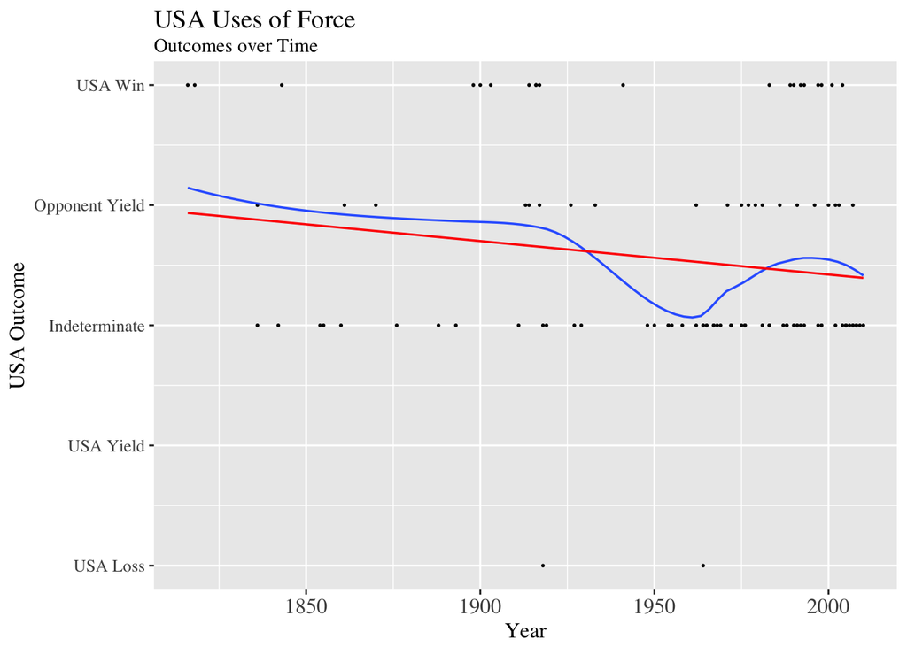

```r
YLabels <- c("USA Loss","USA Yield", "Indeterminate", "Opponent Yield", "USA Win")
ggplot(data = US_Use_of_Force_MIDs_w_outcome_and_location, mapping = aes(x = styear.x, y = USA_Outcome)) + geom_point(size=0.3) + labs(x="Year",y="USA Outcome") +
  theme(axis.text.x = element_text(size = 12), axis.title = element_text(size = 12)) + scale_y_continuous(breaks = 1:5, labels=c("USA Loss","USA Yield","Indeterminate","Opponent Yield","USA Win")) +
  ggtitle('USA Uses of Force', subtitle = 'Outcomes over Time') +
  geom_smooth(se=F, size = 0.6) + geom_smooth(method='lm', color = "red", se=F, size = 0.6)+
  theme(text=element_text(size=12, family="Times"))
```

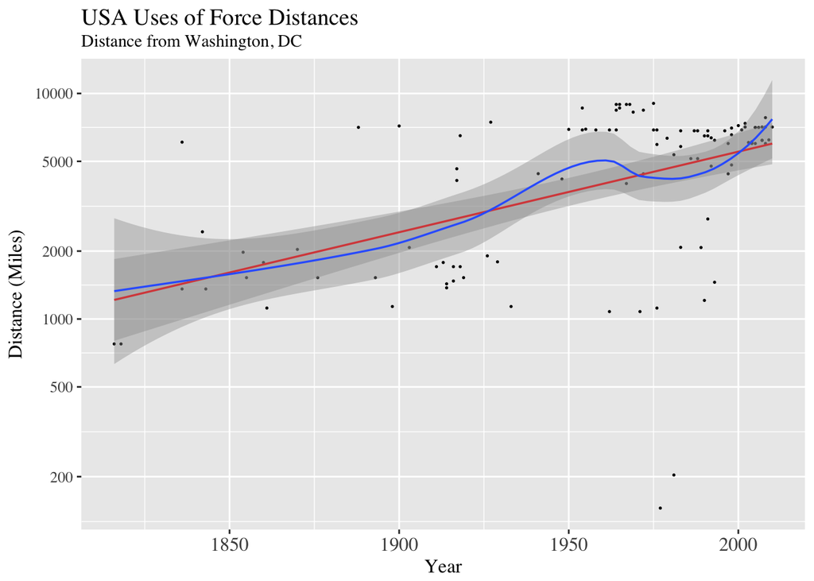

```r
ggplot(data = US_Use_of_Force_MIDs_w_outcome_and_location, mapping = aes(x = styear.x, y = DCDIst)) + geom_point(size=0.25) +  labs(x="Year",y="Distance (Miles)") +
  theme(axis.text.x = element_text(size = 12), axis.title = element_text(size = 12)) +
  scale_y_log10(breaks=c(200,500,1000,2000,5000,10000),labels=c(200,500,1000,2000,5000,10000)) +
  ggtitle('USA Uses of Force Distances', subtitle = 'Distance from Washington, DC') + geom_smooth(method='lm', color = "red", size = 0.6)+
  geom_smooth(size = 0.6) +
  theme(text=element_text(size=12, family="Times"))
```

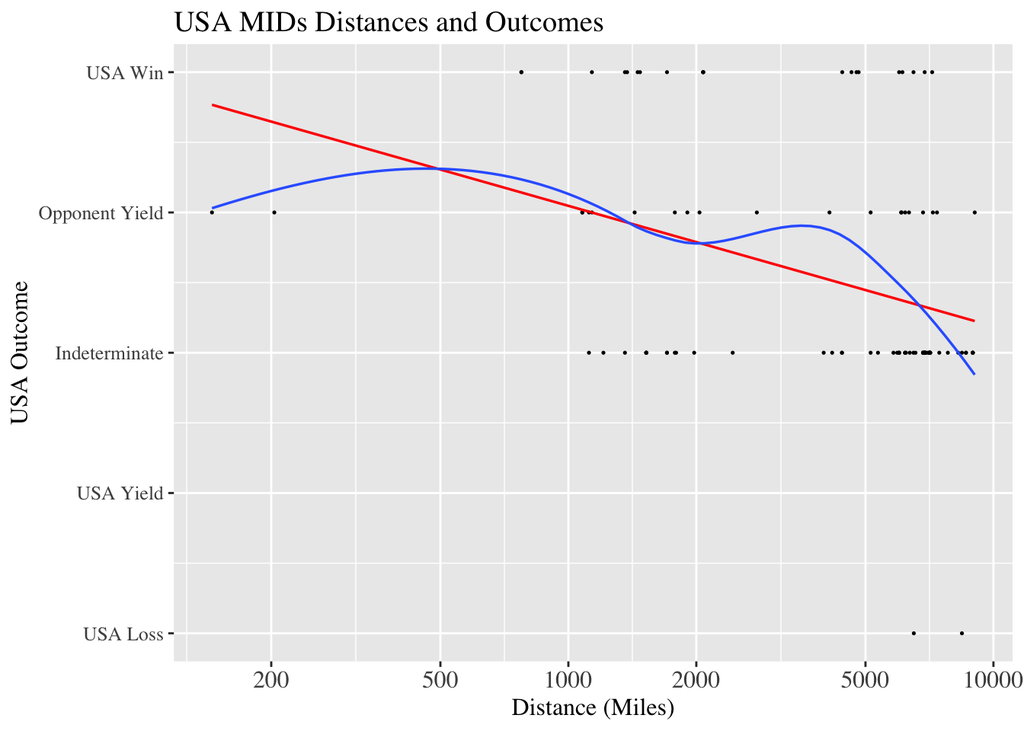

```r
ggplot(data = US_Use_of_Force_MIDs_w_outcome_and_location, mapping = aes(x = DCDIst, y = USA_Outcome)) + geom_point(size=0.25) +  labs(x="Distance (Miles)",y="USA Outcome") +
  theme(axis.text.x = element_text(size = 12), axis.title = element_text(size = 12)) +
  ggtitle('USA MIDs Distances and Outcomes') + geom_smooth(method='lm', color = "red", se=F, size = 0.6)+
  geom_smooth(se=F, size = 0.6) + scale_y_continuous(breaks = 1:5, labels=c("USA Loss","USA Yield","Indeterminate","Opponent Yield","USA Win"))+scale_x_log10(breaks=c(200,500,1000,2000,5000,10000),labels=c(200,500,1000,2000,5000,10000))+
  theme(text=element_text(size=12, family="Times"))
```

```r
m1 <- lm(USA_Outcome ~ styear.x, data = US_Use_of_Force_MIDs_w_outcome_and_location)
m2 <- lm(USA_Outcome ~ log10(DCDIst), data = US_Use_of_Force_MIDs_w_outcome_and_location)
m3 <- lm(USA_Outcome ~ styear.x + log10(DCDIst), data = US_Use_of_Force_MIDs_w_outcome_and_location)
#m4 <- lm(USA_Outcome ~ StYear.x + log10(DCDIst) + HiAct.x, data = US_Use_of_Force_MIDs_w_outcome_and_location)
m4 <- lm(USA_Outcome ~ styear.x + log10(DCDIst) + cinc , data = US_Use_of_Force_MIDs_w_outcome_and_location)
m5 <- lm(USA_Outcome ~ styear.x + log10(DCDIst) + hostlev.x + cinc , data = US_Use_of_Force_MIDs_w_outcome_and_location)



library(stargazer)
stargazer(m1, m2, m3, m4,m5, type="latex",
dep.var.labels=c("Use of Force Outcome for USA"),omit.stat=c("LL","ser","f"),
covariate.labels=c("Year","Log Distance (Miles)", "Intensity of Hostilities", "CINC Score"), out="models.txt")
```

```r
m1 <- lm(USA_Outcome ~ AUMF, data = US_Use_of_Force_MIDs_w_outcome_and_location)
m2 <- lm(USA_Outcome ~ DoW, data = US_Use_of_Force_MIDs_w_outcome_and_location)
m3 <- lm(USA_Outcome ~ DCFA + log10(DCDIst), data = US_Use_of_Force_MIDs_w_outcome_and_location)
#m4 <- lm(USA_Outcome ~ StYear.x + log10(DCDIst) + HiAct.x, data = US_Use_of_Force_MIDs_w_outcome_and_location)
m4 <- lm(USA_Outcome ~ DCFA + styear.x + log10(DCDIst) + cinc , data = US_Use_of_Force_MIDs_w_outcome_and_location)
m5 <- lm(USA_Outcome ~ DCFA + styear.x + log10(DCDIst) + hostlev.x + cinc , data = US_Use_of_Force_MIDs_w_outcome_and_location)


US_Use_of_Force_MIDs_w_outcome_and_location$AUMF
```

[1] 0 0 0 0 0 0 0 0 0 0 1 0 0 0 0 0 0 0 1 0 0 0 0 0 0 0 0 0 0 0 0 0 0 0 0 [36] 0 0 0 0 0 0 1 1 0 0 1 0 0 1 1 0 0 0 0 0 0 0 0 0 0 0 0 1 0 0 0 0 0 0 0 [71] 0 1 1 0 0 0 1 1 0 1 1 0 0 0 0 0 1 0 1 1 1 1 1 1 1 1 0 1 1 1 1 1 1 1

```r
US_Use_of_Force_MIDs_w_outcome_and_location$DoW
```

[1] 0 0 0 0 0 1 0 0 0 0 0 0 0 0 1 0 0 0 0 0 0 0 0 1 0 0 0 0 0 0 0 0 1 0 0 [36] 0 0 0 0 0 0 0 0 0 0 0 0 0 0 0 0 0 0 0 0 0 0 0 0 0 0 0 0 0 0 0 0 0 0 0 [71] 0 0 0 0 0 0 0 0 0 0 0 0 0 0 0 0 0 0 0 0 0 0 0 0 0 0 0 0 0 0 0 0 0 0

```r
US_Use_of_Force_MIDs_w_outcome_and_location$DCFA
```

[1] 0 0 0 0 0 1 0 0 0 0 1 0 0 0 1 0 0 0 1 0 0 0 0 1 0 0 0 0 0 0 0 0 1 0 0 [36] 0 0 0 0 0 0 1 1 0 0 1 0 0 1 1 0 0 0 0 0 0 0 0 0 0 0 0 1 0 0 0 0 0 0 0 [71] 0 1 1 0 0 0 1 1 0 1 1 0 0 0 0 0 1 0 1 1 1 1 1 1 1 1 0 1 1 1 1 1 1 1

```r
library(stargazer)
stargazer(m1, m2, m3, m4,m5, type="latex",
dep.var.labels=c("Use of Force Outcome for USA"),omit.stat=c("LL","ser","f"))
```

```r
#covariate.labels=c("Year","Log Distance (Miles)", "Intensity of Hostilities", "CINC Score"), out="models.txt")
```